# Introduction

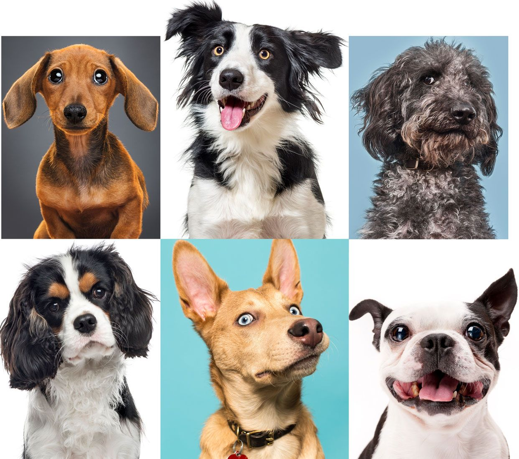

Dog!

Aren't they adorable?

People can get into heated discussions about what is their most faviorate animal, dogs? or cats? Or even parrets! But we can all agree that they are all cute animals.

But what kind of dog do most people like? What are the names that they are likely to name their dogs with? That's what we'll try to find out from this project.

The data represented in this project revolves around what type of dog people like the most and what are the dog types that are most prevelante in the dataset. The 'image_predictions' file tries to guess the type of dogs assigned to each tweet through various image recognition methods. This report aims to touch on the insights that were made about these three dataframes.

# Insight #1:

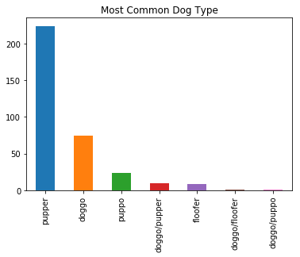

After checking the top dog types in terms of quantity, it seems that the most common dog type is the pupper dog type, followed by the doggo and puppo respectivly. This might be because most of the dogs that the data were collected about were mainly form the pupper type, or maybe the pupper is the most common dog type out there.

# Insight #2:

The Labrador Retriever is the most common dog bread to be identifed by the three algorithems, this is either because the data is biased to this dog bread which means the algorithms are precise, or the three algorithems are more likely to mistakingly brand a dog of a different bread as the Labrador Retriever.

# Insight #3:

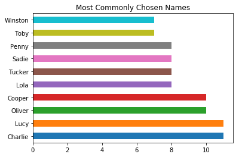

It seems that the most chosen dog names Lucy and Charlie, followed by Oliver and Cooper respectively. However, we can't conclude that these are the names that people are more likely to call their dogs with. Maybe it is due to data bias. We don't really know.

According to dogtime.com, the 4 most common dog names are Bailey, Bella, Max and Lucy.(source:https://dogtime.com/top-100-dog-names)

# Conclusion

In conclusion, the most common dog type found in the data is the Puppor, and the most common dog bread is The Labrador Retriever. And finally, the most common dog names in the dataset are Lucy, Charlie, Oliver and Cooper respectively.

That's all about our lovely dogs for today. Have fun and stay safe!

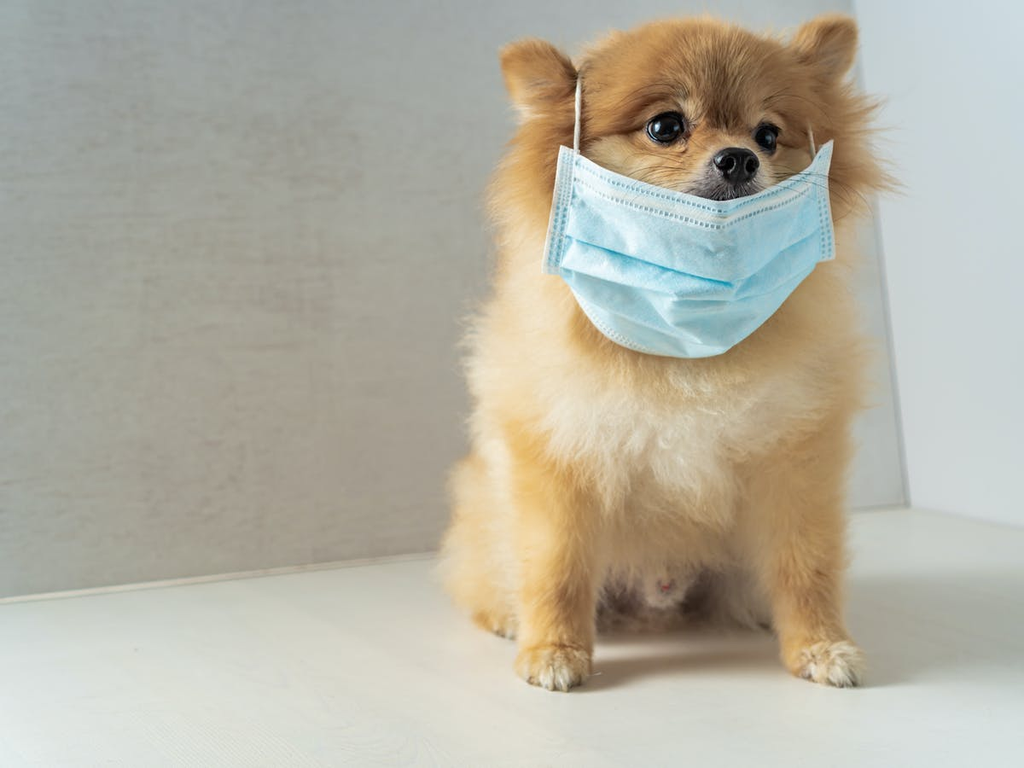

```python
from subprocess import call
call(['python', '-m', 'nbconvert', 'act_report.ipynb'])
```

```
0
```